# Practical ML Course Project

Vidya

8 May 2018

# HAR(Human Activity Recognition) Data Analysis.

Details of the HAR project is provided at : http://web.archive.org/web/20161224072740/http:/groupware.les.inf.puc-rio.br/har.

### Data Analysis Objective:

**We are provided with a fairly large training data set which consists of data collected from wearable device sensors such as Arm band sensors, Belt sensors , Glove sensors and Dumbbell sensors. The training data set has been classified to one of the five classes - A, B,C,D and E. The classes identify whether the excercise has been performed correctly (classe A) or has been performed with error(classes B to E)** **Hence the goal is to apply appropriate machine learning algorithms to the data set so as to predict the class and to have the highest classification accuracy** **Also , once we have the model in place , predict the classes for the 20 observations in the test data set.**

*Further reference to the data is available at :http://web.archive.org/web/20170519033209/http://groupware.les.inf.puc-rio.br:80/public/papers/2013.Velloso.QAR-WLE.pdf.*

### **The steps followed in this excercise is :**

1. Reading and exploring data.
2. Data Cleansing.
3. Split data for training and validation
4. Data Preprocess.
5. Data modelling , starting with less complex methods and keeping an eye for improvement on accuracy.
6. Predict class for test data set with the selected model.

### Large number of variables in the training data.

```r
dim(har_data_train)
```

```
[1] 19622   154
```

### Dimension of the test data.

```r
dim(har_data_test)
```

```
[1]  20 154
```

### Check for NA in training data

```r
nrow(na.omit(har_data_train))
```

```
[1] 406
```

### Check for NA in test data

```r
nrow(na.omit(har_data_test))
```

```
[1] 0
```

## Data Cleaning : Training Data

It is observed that the training data has 19216 rows of NA values and all the test data rows seem to have some variables with NA values . Hence we need to impute values for NA .

NA values can be imputed with preprocess function of caret and use methods such as knnImpute or medianImpute . But since test data does not have any rows which have no NA values, knnImpute and medianImpute methods are unable to provide the imputed values for NA in test data set.

Hence modelling is tried with imputing NA with zero in the train as well as test data set.

```r
## Check for which columns have NA values
na_list <- apply(har_data_train , 2 , is.na)

na_sum_list <- apply(na_list , 2 , sum)

## Names of columns with NA
na_cols <- names(na_sum_list[na_sum_list > 0])

## Names of columns that don't have NA
no_na_cols <- names(na_sum_list[na_sum_list == 0])

## Imputing NA with zero

temp <- data.frame(sapply(har_data_train[,na_cols] , function(x){ifelse(is.na(x), 0 , x)}))

## Combine the imputed columns and those that don't have NA

har_data_train1 <- cbind(temp , har_data_train[,no_na_cols])
```

Some more cleansing of training data i.e converting blanks and character values like ‘#DIV/0!’ to zero numeric.

```r
## Impute blank character values and '#DIV/0!' to zero

x_class <- sapply(har_data_train1 , class)

x_char <- x_class[x_class=="character"]

x_intnum <- x_class[x_class =="numeric" | x_class =="integer" ]

## We dont' need to convert 'classe' to numeric
x_char <- x_char[-34]

temp1 <- data.frame(sapply(har_data_train1[,names(x_char)] , function(x){ifelse((x == "")|x == "#DIV/0!" , 0 , x)}))

## Mass formatting of character class variables to numeric class.
temp2 <- as.data.frame(sapply(temp1 , as.numeric))

## Cleansed training data is now ready for further processing.
har_data_train_final <- cbind(temp2 , har_data_train1[,names(x_intnum)] ,"classe" = har_data_train1$classe )
```

## Data Cleansing : Test data .

We need to treat test data to similar data cleansing as in training data , i.e impute NA values , ensure all the predictors as numeric variables .

```r
## Check for which columns have NA values
na_list_test <- apply(har_data_test , 2 , is.na)

na_sum_list_test <- apply(na_list_test , 2 , sum)

## Names of columns with NA
na_cols_test <- names(na_sum_list_test[na_sum_list_test > 0])

## Names of columns that don't have NA
no_na_cols_test <- names(na_sum_list_test[na_sum_list_test == 0])

## Imputing NA with zero
temp <- data.frame(sapply(har_data_test[,na_cols_test] , function(x){ifelse(is.na(x), 0 , x)}))

## Combine the imputed columns and those that don't have NA

har_data_test1 <- cbind(temp , har_data_test[,no_na_cols_test])

## Last column in the test data is the problem id . Exclude it from the test data .
har_data_test_final <- har_data_test1[,-154]
```

Next , Split training data into two sub sets for model creation and model validation. This is done with createDataPartition function in caret.

```r
set.seed(1212)
inTrain <- createDataPartition(har_data_train_final$classe , p =0.75 , list = FALSE)

training <- har_data_train_final[inTrain,]

table(training$classe)
```

```
   A    B    C    D    E
4185 2848 2567 2412 2706
```

```r
testing <- har_data_train_final[-inTrain,]
```

### Pre Processing of Training data :-

Checking for variables in training data set that have nearzero variance.This is required as during dimensionality reduction with principal component analysis, variables with very low variance are to be omitted.

```r
nzv <- nearZeroVar(training[,-154] , saveMetrics = TRUE)

head(nzv)
```

```
                     freqRatio percentUnique zeroVar  nzv
kurtosis_roll_belt       14428   1.977170811   FALSE TRUE
kurtosis_picth_belt       3611   1.637450741   FALSE TRUE
kurtosis_yaw_belt            0   0.006794401    TRUE TRUE
skewness_roll_belt        4809   1.970376410   FALSE TRUE
skewness_roll_belt.1      3611   1.712189156   FALSE TRUE
skewness_yaw_belt            0   0.006794401    TRUE TRUE
```

```r
range(nzv$percentUnique)
```

```
[1]  0.006794401 86.261720342
```

```r
## How many variables have zero variance ?
print(length(nzv[nzv$zeroVar == TRUE,]))
```

```
[1] 4
```

```r
nzv <- nearZeroVar(training)

## Omit the nzv variables from training and testing subsets as well as final test data set.
filtered_train <- training[,-nzv]

filtered_test <- testing[,names(filtered_train)]

filtered_har_data_test <- har_data_test_final[,names(filtered_train[,-54])]
```

### Variables as input for modelling :

```r
names(filtered_train)
```

```
 [1] "num_window"           "roll_belt"            "pitch_belt"
 [4] "yaw_belt"             "total_accel_belt"     "gyros_belt_x"
 [7] "gyros_belt_y"         "gyros_belt_z"         "accel_belt_x"
[10] "accel_belt_y"         "accel_belt_z"         "magnet_belt_x"
[13] "magnet_belt_y"        "magnet_belt_z"        "roll_arm"
[16] "pitch_arm"            "yaw_arm"              "total_accel_arm"
[19] "gyros_arm_x"          "gyros_arm_y"          "gyros_arm_z"
[22] "accel_arm_x"          "accel_arm_y"          "accel_arm_z"
[25] "magnet_arm_x"         "magnet_arm_y"         "magnet_arm_z"
[28] "roll_dumbbell"        "pitch_dumbbell"       "yaw_dumbbell"
[31] "total_accel_dumbbell" "gyros_dumbbell_x"     "gyros_dumbbell_y"
[34] "gyros_dumbbell_z"     "accel_dumbbell_x"     "accel_dumbbell_y"
[37] "accel_dumbbell_z"     "magnet_dumbbell_x"    "magnet_dumbbell_y"
[40] "magnet_dumbbell_z"    "roll_forearm"         "pitch_forearm"
[43] "yaw_forearm"          "total_accel_forearm"  "gyros_forearm_x"
[46] "gyros_forearm_y"      "gyros_forearm_z"      "accel_forearm_x"
[49] "accel_forearm_y"      "accel_forearm_z"      "magnet_forearm_x"
[52] "magnet_forearm_y"     "magnet_forearm_z"     "classe"
```

### Dimensionality reduction - PCA on the training data as well as test data .

```r
set.seed(345)
pca_train <- preProcess(filtered_train, method = "pca")

pca_predicted <- predict(pca_train , filtered_train)

pca_testing <- predict(pca_train , filtered_test)

pca_har_data_test <- predict(pca_train , filtered_har_data_test)
```

## Performing classification with Decision Trees on the principal components.

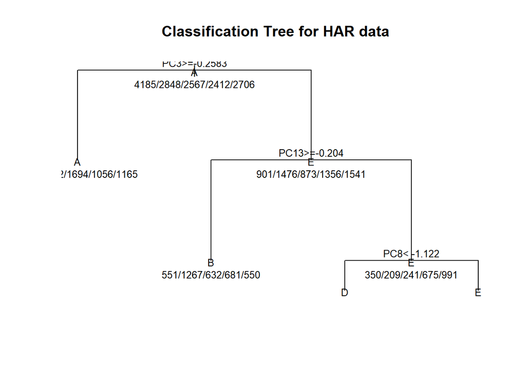

```r
fitcontrol <- trainControl(method = "repeatedcv" , number = 5 , repeats = 5)

pca_mod <- train(classe ~ . , data = pca_predicted , method = "rpart", trControl = fitcontrol)

plot(pca_mod$finalModel , main ="Classification Tree for HAR data ")
text(pca_mod$finalModel  , cex = 0.8 , all = TRUE , use.n = TRUE)
```

```r
## Classe C not predicted

class_predicted <- predict(pca_mod , pca_predicted)

confusionMatrix(class_predicted , pca_predicted$classe)
```

```
Confusion Matrix and Statistics

          Reference
Prediction    A    B    C    D    E
         A 3284 1372 1694 1056 1165
         B  551 1267  632  681  550
         C    0    0    0    0    0
         D   75   91   22  384  171
         E  275  118  219  291  820

Overall Statistics

               Accuracy : 0.391
                 95% CI : (0.3831, 0.399)
    No Information Rate : 0.2843
    P-Value [Acc > NIR] : < 2.2e-16

                  Kappa : 0.1947
 Mcnemar's Test P-Value : < 2.2e-16

Statistics by Class:

                     Class: A Class: B Class: C Class: D Class: E
Sensitivity            0.7847  0.44487   0.0000  0.15920  0.30303
Specificity            0.4981  0.79663   1.0000  0.97083  0.92483
Pos Pred Value         0.3832  0.34420      NaN  0.51682  0.47591
Neg Pred Value         0.8534  0.85675   0.8256  0.85488  0.85487
Prevalence             0.2843  0.19350   0.1744  0.16388  0.18386
Detection Rate         0.2231  0.08609   0.0000  0.02609  0.05571
Detection Prevalence   0.5823  0.25010   0.0000  0.05048  0.11707
Balanced Accuracy      0.6414  0.62075   0.5000  0.56502  0.61393
```

```r
class_predicted_test <- predict(pca_mod , pca_testing)

confusionMatrix(class_predicted_test , pca_testing$classe)
```

```
Confusion Matrix and Statistics

          Reference
Prediction    A    B    C    D    E
         A 1064  450  539  362  397
         B  212  411  232  243  199
         C    0    0    0    0    0
         D   24   46    9  101   46
         E   95   42   75   98  259

Overall Statistics

               Accuracy : 0.3742
                 95% CI : (0.3606, 0.3879)
    No Information Rate : 0.2845
    P-Value [Acc > NIR] : < 2.2e-16

                  Kappa : 0.1731
 Mcnemar's Test P-Value : < 2.2e-16

Statistics by Class:

                     Class: A Class: B Class: C Class: D Class: E
Sensitivity            0.7627  0.43309   0.0000  0.12562  0.28746
Specificity            0.5019  0.77598   1.0000  0.96951  0.92256
Pos Pred Value         0.3784  0.31689      NaN  0.44690  0.45518
Neg Pred Value         0.8418  0.85085   0.8257  0.84972  0.85190
Prevalence             0.2845  0.19352   0.1743  0.16395  0.18373
Detection Rate         0.2170  0.08381   0.0000  0.02060  0.05281
Detection Prevalence   0.5734  0.26448   0.0000  0.04608  0.11603
Balanced Accuracy      0.6323  0.60453   0.5000  0.54757  0.60501
```

It can be seen that classe ’C’is not predicted and the test set accuracy is 0.3741843.

### Next , perform Bagged Tree modelling for accuracy improvement.

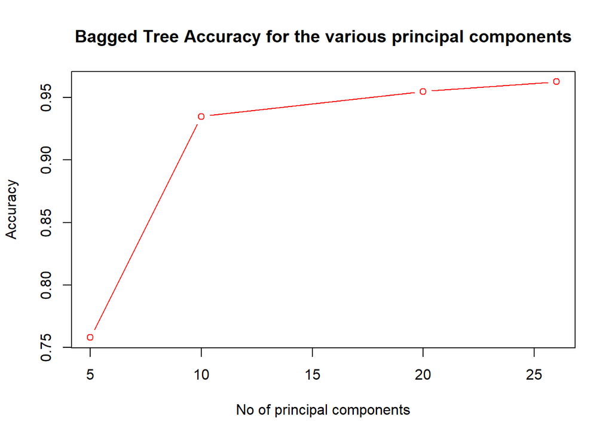

```r
fitcontrol <- trainControl(method = "repeatedcv" , number = 5 , repeats = 5)

accuracy <- numeric()
pcomp <- c(5,10,20)

pcomp <- c(pcomp , ncol(pca_predicted))
for(i in pcomp){

set.seed(123)

bagtree_mod  <- train(classe ~ . , data = pca_predicted[, 1:i] , method = "treebag" , trControl = fitcontrol )

bagtree_pred_train <- predict(bagtree_mod , pca_testing[,1:i])

confusionMatrix(bagtree_pred_train , pca_testing$classe)


accuracy[i] <- confusionMatrix(bagtree_pred_train , pca_testing$classe)$overall['Accuracy']

}

plot(pcomp , accuracy[pcomp] , main = " Bagged Tree Accuracy for the various principal components " , xlab = "No of principal components" , ylab = "Accuracy" , col = "red", type ="b" )
```

### Predict the Classes for the given test data which consists of 20 observations .

```r
bagtree_pred_test <- predict(bagtree_mod , pca_har_data_test)

bagtree_pred_test
```

```
 [1] B A A A A E D B A A B C B A E E A B B B
Levels: A B C D E
```

```r
table(bagtree_pred_test)
```

```
bagtree_pred_test
A B C D E
8 7 1 1 3
```

### Random forest

Finally , evalute Random Forest for further improvement in accuracy.

```r
forest_mod <- train(classe ~ . , data = pca_predicted[,1:20] , method = "rf")

forest_mod
```

```
Random Forest

14718 samples
   19 predictor
    5 classes: 'A', 'B', 'C', 'D', 'E'

No pre-processing
Resampling: Bootstrapped (25 reps)
Summary of sample sizes: 14718, 14718, 14718, 14718, 14718, 14718, ...
Resampling results across tuning parameters:

  mtry  Accuracy   Kappa
   2    0.9636880  0.9540647
  10    0.9569793  0.9455840
  19    0.9486207  0.9350148

Accuracy was used to select the optimal model using  the largest value.
The final value used for the model was mtry = 2.
```

```r
forest_pred <- predict(forest_mod , pca_testing[,1:20] )

confusionMatrix(forest_pred , pca_testing$classe)
```

```
Confusion Matrix and Statistics

          Reference
Prediction    A    B    C    D    E
         A 1383   20    1    1    0
         B    1  918    9    1    2
         C    5   11  838   35    3
         D    6    0    6  765    3
         E    0    0    1    2  893

Overall Statistics

               Accuracy : 0.9782
                 95% CI : (0.9737, 0.9821)
    No Information Rate : 0.2845
    P-Value [Acc > NIR] : < 2.2e-16

                  Kappa : 0.9724
 Mcnemar's Test P-Value : NA

Statistics by Class:

                     Class: A Class: B Class: C Class: D Class: E
Sensitivity            0.9914   0.9673   0.9801   0.9515   0.9911
Specificity            0.9937   0.9967   0.9867   0.9963   0.9993
Pos Pred Value         0.9843   0.9860   0.9395   0.9808   0.9967
Neg Pred Value         0.9966   0.9922   0.9958   0.9905   0.9980
Prevalence             0.2845   0.1935   0.1743   0.1639   0.1837
Detection Rate         0.2820   0.1872   0.1709   0.1560   0.1821
Detection Prevalence   0.2865   0.1898   0.1819   0.1591   0.1827
Balanced Accuracy      0.9926   0.9820   0.9834   0.9739   0.9952
```

Thus we see that the prediction Accuracy is increased by Random Forest method and is 0.9781811.